# DU-Bii Study cases - Mouse fibrotic kidney

# Gene filtered boxplot

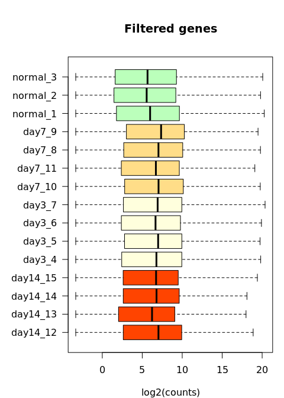

```r
#### Box plots after filtering ####
par(mar = c(4, 6, 5, 1))
boxplot(log2CountsFiltered,
        col = metadata$color,
        horizontal = TRUE,
        las = 1,
        main = "Filtered genes",
        xlab = "log2(counts)")
```

```r
par(par.ori)
```

# Normalisation (more precisely: scaling)

Before going any further, it is important to ensure some normalisation of the counts, in order to correct for biases due to inter-sample differences in sequencing depth.

For the sake of simplicity, we will use here a very simple criterion: median-based normalisation. The principle is to multiply the counts of each sample by a scaling factor in order to bring each sample to the same median count.

# Normalisation code

```r
#### Median-based normalisation ####
sampleMedians <- apply(log2CountsFiltered, 2, median)
seriesMedian <- median(sampleMedians)
scalingFactors <- seriesMedian / sampleMedians

log2CountsStandardised <- data.frame(matrix(
  nrow = nrow(log2CountsFiltered),
  ncol = ncol(log2CountsFiltered)))
colnames(log2CountsStandardised) <- colnames(log2CountsFiltered)
rownames(log2CountsStandardised) <- rownames(log2CountsFiltered)
for (j in 1:ncol(log2CountsFiltered)) {
  log2CountsStandardised[, j] <- log2CountsFiltered[, j] * scalingFactors[j]
}

## Check the remaining medians
apply(log2CountsStandardised, 2, median)
```

```
day14_12 day14_13 day14_14 day14_15   day3_4   day3_5   day3_6   day3_7  day7_10  day7_11   day7_8   day7_9 normal_1 normal_2 normal_3
6.772065 6.772065 6.772065 6.772065 6.772065 6.772065 6.772065 6.772065 6.772065 6.772065 6.772065 6.772065 6.772065 6.772065 6.772065
```

# Normalized boxplot

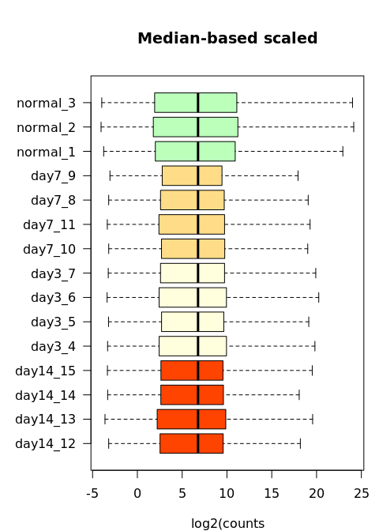

```r
#### Box plots after scaling ####
par(mar = c(4, 6, 5, 1))
boxplot(log2CountsStandardised,
        col = metadata$color,
        horizontal = TRUE,
        las = 1,
        main = "Median-based scaled",
        xlab = "log2(counts")
```

```r
par(par.ori)
```

# Violin plots

We can also inspect the distribution of counts per sample with the `vioplot()` function.

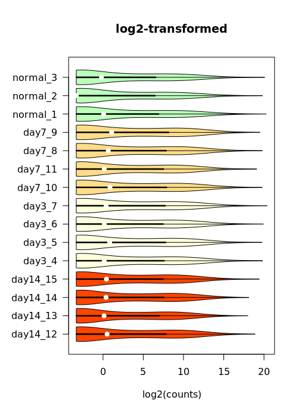

```r
#### Violin plots ####
par(mar = c(4, 6, 5, 1))
vioplot::vioplot(log2Counts,
        col = metadata$color,
        horizontal = TRUE,
        las = 1,
        main = "log2-transformed",
        xlab = "log2(counts)")
```

```r
par(par.ori)
```

# Scatter plots

We can also inspect the distribution of counts per sample with the `plot()` function.

[figure not shown]

```r
#### Scatter plots ####
par(mar = c(4, 6, 5, 1))
plot(log2Counts[,metadata$sampleName],
        col = metadata$color)
```

```r
par(par.ori)
```